# Коан о простой линейной регрессии {#simplereg}

Построим простую линейную регрессию в R и проведем несложные тесты.

Загрузим необходимые пакеты.

```r
library(tidyverse) # для манипуляций с данными и построения графиков
library(skimr) # для красивого summary
library(rio) # для чтения .dta файлов
library(car) # для линейных гипотез
library(tseries) # для теста на нормальность
library(sjPlot) # еще графики
```

Импортируем данные.

```r
df = rio::import("us-return.dta")
```

Исследуем наш датасет.

```r
skim_with(numeric = list(hist = NULL, p25 = NULL, p75 = NULL)) # опустим некоторые описательные характеристики
skim(df) # посмотрим на данные
```

```
Skim summary statistics
 n obs: 2664
 n variables: 22

-- Variable type:character -----------------------------------------------------
 variable missing complete    n min max empty n_unique
        B       0     2664 2664   0   6  2544       31

-- Variable type:numeric -------------------------------------------------------
 variable missing complete    n    mean      sd      p0     p50    p100
        A    2544      120 2664 60.5    34.79    1      60.5    120
    BOISE    2544      120 2664  0.017   0.097  -0.27    0.015    0.38
   CITCRP    2544      120 2664  0.012   0.081  -0.28    0.011    0.32
    CONED    2544      120 2664  0.019   0.05   -0.14    0.019    0.15
   CONTIL    2544      120 2664 -0.0011  0.15   -0.6     0        0.97
   DATGEN    2544      120 2664  0.0075  0.13   -0.34    0.017    0.53
      DEC    2544      120 2664  0.02    0.099  -0.36    0.024    0.38
    DELTA    2544      120 2664  0.012   0.096  -0.26    0.013    0.29
   GENMIL    2544      120 2664  0.017   0.065  -0.15    0.011    0.19
   GERBER    2544      120 2664  0.016   0.088  -0.29    0.015    0.23
      IBM    2544      120 2664  0.0096  0.059  -0.19    0.002    0.15
   MARKET    2544      120 2664  0.014   0.068  -0.26    0.012    0.15
    MOBIL    2544      120 2664  0.016   0.08   -0.18    0.012    0.37
    MOTOR    2544      120 2664  0.018   0.097  -0.33    0.016    0.27
    PANAM    2544      120 2664  0.0035  0.13   -0.31    0        0.41
     PSNH    2544      120 2664 -0.0042  0.11   -0.48    0        0.32
   rkfree    2544      120 2664  0.0068  0.0022  0.0021  0.0066   0.013
   RKFREE    2544      120 2664  0.0068  0.0022  0.0021  0.0066   0.013
    TANDY    2544      120 2664  0.025   0.13   -0.25    0.022    0.45
   TEXACO    2544      120 2664  0.012   0.08   -0.19    0.01     0.4
    WEYER    2544      120 2664  0.0096  0.085  -0.27   -0.002    0.27
```

```r
df = rename(df, n = A, date = B) # дадим столбцам более осмысленные названия
```

```r
df = na.omit(df) # уберем пустые строки
```

Будем верить в CAPM :) Оценим параметры модели для компании MOTOR. Соответственно, зависимая переменная - разница доходностей акций MOTOR и безрискового актива, а регрессор - рыночная премия.

```r
#создаем новые переменные и добавляем их к набору данных
df = mutate(df, y = MOTOR - RKFREE, x = MARKET - RKFREE)
```

Строим нашу модель и проверяем гипотезу об адекватности регрессии.

```r
ols = lm(y ~ x, data = df)
summary(ols)
```

```
Call:
lm(formula = y ~ x, data = df)

Residuals:
      Min        1Q    Median        3Q       Max
-0.168421 -0.059381 -0.003399  0.061373  0.182991

Coefficients:
            Estimate Std. Error t value Pr(>|t|)
(Intercept) 0.005253   0.007200   0.730    0.467
x           0.848150   0.104814   8.092 5.91e-13 ***
---
Signif. codes:  0 '***' 0.001 '**' 0.01 '*' 0.05 '.' 0.1 ' ' 1

Residual standard error: 0.07844 on 118 degrees of freedom
Multiple R-squared:  0.3569,    Adjusted R-squared:  0.3514
F-statistic: 65.48 on 1 and 118 DF,  p-value: 5.913e-13
```

Вызовом одной функции получаем кучу полезных графиков. Можем визуально оценить наличие гетероскедастичности, нормальность распределения остатков, наличие выбросов.

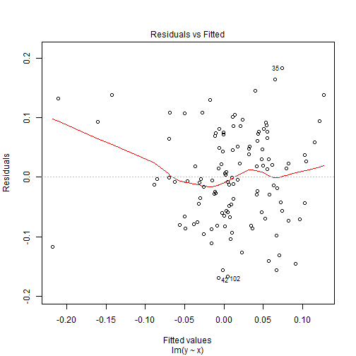

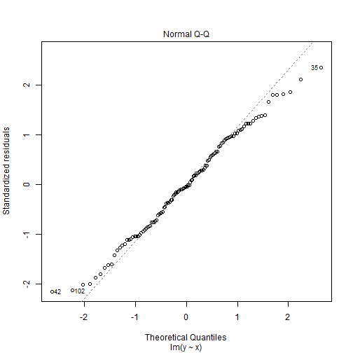

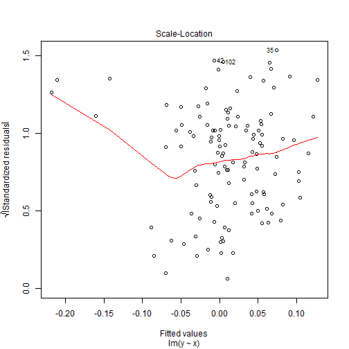

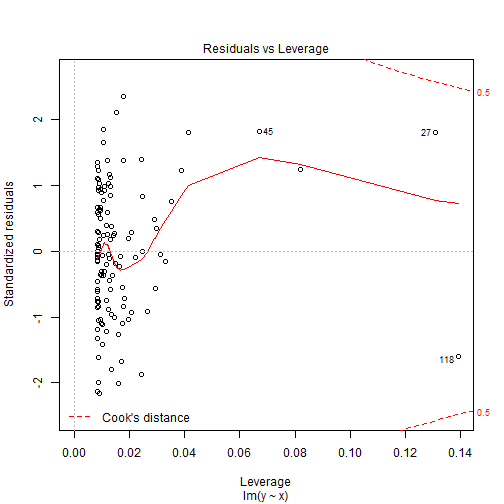

```r
plot(ols)
```

Строим доверительный интервал для параметров модели.

```r
est = cbind(Estimate = coef(ols), confint(ols))
```

[output not shown]

Проверим гипотезу о равенстве коэффициента при регрессоре единице.

```r
linearHypothesis(ols, c("x = 1"))
```

```
Linear hypothesis test

Hypothesis:
x = 1

Model 1: restricted model
Model 2: y ~ x

  Res.Df     RSS Df Sum of Sq      F Pr(>F)
1    119 0.73900
2    118 0.72608  1  0.012915 2.0989 0.1501
```

Посмотрим на остатки :) Протестируем остатки регрессии на нормальность с помощью теста Харке-Бера.

\[H_{0}: S = 0, K = 3,\ \text{где S — коэффициент асимметрии (Skewness), K — коэффициент эксцесса (Kurtosis)}\]

```r
jarque.bera.test(resid(ols))
```

```
    Jarque Bera Test

data:  resid(ols)
X-squared = 1.7803, df = 2, p-value = 0.4106
```

И тест Шапиро-Уилка.

\(H_{0}: \epsilon_{i} \sim N(\mu,\sigma^2)\)

```r
shapiro.test(resid(ols))
```

```
    Shapiro-Wilk normality test

data:  resid(ols)
W = 0.99021, p-value = 0.5531
```

Оба теста указывают на нормальность распределения остатков регрессии.

Сделаем прогноз модели по данным вне обучаемой выборки.

```r
set.seed(7)

newData = data.frame(x = df$x+0.5*rnorm(length(df$x))) #пошумим
yhat = predict(ols, newdata = newData, se = TRUE)
```

#### То же самое в стате

Загружаем данные.

```stata
use us-return.dta
```

Любуемся и даем новые названия столбцам.

```stata
summarize
ren A n
ren B date
```

```
    Variable |       Obs        Mean    Std. Dev.       Min        Max
-------------+--------------------------------------------------------
           A |       120        60.5    34.78505          1        120
           B |         0
       MOBIL |       120    .0161917    .0803075      -.178       .366
      TEXACO |       120    .0119417    .0797036      -.194       .399
         IBM |       120    .0096167     .059024      -.187        .15
-------------+--------------------------------------------------------
         DEC |       120      .01975    .0991438      -.364       .385
      DATGEN |       120    .0074833    .1275399      -.342       .528
       CONED |       120    .0185083    .0502719      -.139       .151
        PSNH |       120   -.0042167    .1094712      -.485       .318
       WEYER |       120    .0096333    .0850664      -.271        .27
-------------+--------------------------------------------------------
       BOISE |       120     .016675    .0974882      -.274       .379
       MOTOR |       120    .0181583    .0972656      -.331        .27
       TANDY |       120    .0250083     .127566      -.246       .454
       PANAM |       120    .0035167    .1318054      -.313       .406
       DELTA |       120    .0116917    .0959317       -.26       .289
-------------+--------------------------------------------------------
      CONTIL |       120      -.0011    .1506992        -.6       .974
      CITCRP |       120    .0118583    .0809719      -.282       .318
      GERBER |       120       .0164    .0877379      -.288       .234
      GENMIL |       120    .0165833    .0650403      -.148        .19
      MARKET |       120    .0139917    .0683532       -.26       .148
-------------+--------------------------------------------------------
      RKFREE |       120    .0068386    .0021869     .00207     .01255
      rkfree |       120    .0068386    .0021869     .00207     .01255
```

Убираем пропущенные значения и создаем новые переменные.

```stata
drop if n == .
gen y = MOTOR-RKFREE
gen x = MARKET-RKFREE
```

```
(2544 observations deleted)
```

Строим модель и проверяем гипотезу об адекватности регрессии. Тут же получаем доверительные интервалы для коэффициентов.

```stata
reg y x
```

```
      Source |       SS       df       MS              Number of obs =     120
-------------+------------------------------           F(  1,   118) =   65.48
       Model |  .402913404     1  .402913404           Prob > F      =  0.0000
    Residual |  .726081541   118  .006153233           R-squared     =  0.3569
-------------+------------------------------           Adj R-squared =  0.3514
       Total |  1.12899494   119  .009487352           Root MSE      =  .07844

------------------------------------------------------------------------------
           y |      Coef.   Std. Err.      t    P>|t|     [95% Conf. Interval]
-------------+----------------------------------------------------------------
           x |   .8481496   .1048138     8.09   0.000     .6405898    1.055709
       _cons |   .0052529   .0071999     0.73   0.467     -.009005    .0195107
------------------------------------------------------------------------------
```

Проверим гипотезу о равенстве коэффициента при регрессоре единице.

```stata
test x=1
```

```
 ( 1)  x = 1

       F(  1,   118) =    2.10
            Prob > F =    0.1501
```

Сделаем предсказание по выборке и сохраним остатки.

```stata
predict u_hat, resid
predict y_hat
```

```
(option xb assumed; fitted values)
```

Протестируем остатки регрессии на нормальность с помощью теста Харке-Бера. На самом деле, это не совсем тест Харке-Бера. Оригинальный вариант ассимптотический и в нем нет поправки на размер выборки. В Stata есть. Подробнее здесь https://www.stata.com/manuals13/rsktest.pdf

```stata
sktest u_hat
```

```
                    Skewness/Kurtosis tests for Normality
                                                         ------- joint ------
    Variable |    Obs   Pr(Skewness)   Pr(Kurtosis)  adj chi2(2)    Prob>chi2
-------------+---------------------------------------------------------------
       u_hat |    120      0.8841         0.1027         2.74         0.2539
```

И тест Шапиро-Уилка. Тут все аналогично R.

```stata
swilk u_hat
```

```
                   Shapiro-Wilk W test for normal data

    Variable |    Obs       W           V         z       Prob>z
-------------+--------------------------------------------------
       u_hat |    120    0.99021      0.942    -0.133    0.55310
```

Гипотеза о нормальности остатков не отвергается.

QQ - график

```stata
qnorm u_hat
```

[output not shown]

[output not shown]

[output not shown]

[output not shown]

```stata
set seed 7

set obs 120
gen x_new = x+ 0.5 *rnormal()
gen y_hat_new =  .8481496 * x_new+ .0052529
```

```
obs was 120, now 120
```

#### То же самое в python

Много хорошихх функций для статистических расчетов можно найти в пакете Statsmodels.

```python
import pandas as pd # для работы с таблицами
```

[output not shown]

```python
import numpy as np # математика, работа с матрицами
import matplotlib.pyplot as plt # графики
import statsmodels.api as sm
```

[output not shown]

```python
import statsmodels.formula.api as smf
```

[output not shown]

```python
import statsmodels.graphics.gofplots as gf
```

[output not shown]

```python
from statsmodels.stats.outliers_influence import summary_table
```

[output not shown]

```python
import seaborn as sns # еще более классные графики
```

[output not shown]

```python
from scipy.stats import shapiro # еще математика
import statsmodels.discrete.discrete_model
```

[output not shown]

При желании, можем кастомизировать графики :)

```python
plt.style.use('seaborn')
plt.rc('font', size=14)
plt.rc('figure', titlesize=15)
plt.rc('axes', labelsize=15)
plt.rc('axes', titlesize=15)
```

Загрузим данные.

```python
df = pd.read_stata('us-return.dta')
```

[output not shown]

Избавимся от наблюдений с пропущенными значенями.

```python
df.dropna(inplace=True) ##ИСПРАВИТЬ (выкинуть только пропуски целевой и объяснющей)
```

[output not shown]

```python
df.reset_index(drop=True, inplace=True)
```

[output not shown]

Переименуем столбцы.

```python
df = df.rename(columns={'A':'n', 'B': 'date'})
```

[output not shown]

```python
df['y'] = df['MOTOR'] - df['RKFREE']
```

[output not shown]

```python
df['x'] = df['MARKET'] - df['RKFREE']
```

[output not shown]

Строим модель и читаем саммари :)

```python
regr = smf.ols('y~x', data = df).fit()
```

[output not shown]

```python
regr.summary()
```

[output not shown]

Получить прогноз.

```python
df['yhat'] = regr.fittedvalues
```

[output not shown]

Красивые графики для остатков, выборосов и прочих радостей, как в R, придется строить ручками. Зато приятно поиграть с оформлением :)

```python
fig, ax = plt.subplots()
ax.plot(df['x'],regr.fittedvalues, color='g', alpha =0.8)
```

[output not shown]

```python
ax.scatter(df['x'],regr.fittedvalues+regr.resid, color = 'g', alpha = 0.8, s = 40)
```

[output not shown]

```python
ax.vlines(df['x'],regr.fittedvalues,regr.fittedvalues+regr.resid, color = 'gray', alpha = 0.5)
```

[output not shown]

[figure not shown]

```python
plt.title('Линия регрессии и остатки')
plt.xlabel('RKFREE')
plt.ylabel('MARKET')
plt.show()
```

Строим доверительный интервал.

```python
regr.conf_int()
```

[output not shown]

И проведем F-test.

```python
hypotheses = '(x = 1)'
regr.f_test(r_matrix = hypotheses)
```

[output not shown]

Тест Шапиро. Такой же, как и в R. Для удобства можно поместить в табличку.

```python
W, p_value = shapiro(regr.resid)
```

[output not shown]

```python
pd.DataFrame(data = {'W': [round(W,3)], 'p_value': [round(p_value,3)]})
```

[output not shown]

Генерируем новые данные и строим предсказание.

```python
import random
random.seed(7)

newData = df['x'] + 0.5*np.random.normal(len(df))
prediction = regr.predict(newData)
```

А теперь жесть! Построим графички, похожие на autoplot R.

```python
fig_1 = plt.figure(1)

fig_1.axes[0] = sns.residplot(df['x'], df['y'],
                                  lowess=True,
                                  scatter_kws={'alpha': 0.6},
                                  line_kws={'color': 'red', 'lw': 2, 'alpha': 0.8})

fig_1.axes[0].set_title('Residuals vs Fitted')
fig_1.axes[0].set_xlabel('Fitted values')
fig_1.axes[0].set_ylabel('Residuals')


#можем добавить метки потенциальных аутлаеров
abs_resid = abs(regr.resid).sort_values(ascending=False)
abs_resid_top3 = abs_resid[:3]

for i in abs_resid_top3.index:
    fig_1.axes[0].annotate(i,
                               xy=(regr.fittedvalues[i],
                                   regr.resid[i]))
```

[output not shown]

```python
norm_residuals = regr.get_influence().resid_studentized_internal #сохраним стьюдентизированные остатки
```

[output not shown]

```python
QQ = gf.ProbPlot(norm_residuals)
fig_2 = QQ.qqplot(line='45', alpha=0.5, color='b', lw=1)


fig_2.axes[0].set_title('Normal Q-Q')
fig_2.axes[0].set_xlabel('Theoretical Quantiles')
fig_2.axes[0].set_ylabel('Standardized Residuals');

#и снова метки
abs_norm_resid = np.flip(np.argsort(abs(norm_residuals)), 0)
abs_norm_resid_top3 = abs_norm_resid[:3]

for r, i in enumerate(abs_norm_resid_top3):
    fig_2.axes[0].annotate(i,
                               xy=(np.flip(QQ.theoretical_quantiles, 0)[r],
                                   norm_residuals[i]))
```

```python
fig_3 = plt.figure(3)

plt.scatter(regr.fittedvalues, np.sqrt(abs(norm_residuals)), alpha=0.5)
sns.regplot(regr.fittedvalues, np.sqrt(abs(norm_residuals)),
            scatter=False,
            ci=False,
            lowess=True,
            line_kws={'color': 'red', 'lw': 1, 'alpha': 0.6})

fig_3.axes[0].set_title('Scale-Location')
fig_3.axes[0].set_xlabel('Fitted values')
fig_3.axes[0].set_ylabel('$\sqrt{|Standardized Residuals|}$')

# и еще раз!)
abs_sq_norm_resid = np.flip(np.argsort(np.sqrt(abs(norm_residuals)), 0))
abs_sq_norm_resid_top3 = abs_sq_norm_resid[:3]

for i in abs_sq_norm_resid_top3:
    fig_3.axes[0].annotate(i, xy=(regr.fittedvalues[i],
                                   np.sqrt(abs(norm_residuals)[i])))
```

```python
leverage = regr.get_influence().hat_matrix_diag #сохраняем элементы матрицы-шляпницы
```

[output not shown]

```python
cook_dist = regr.get_influence().cooks_distance[0] #И расстояние Кука

fig_4 = plt.figure(4)

plt.scatter(leverage, norm_residuals, alpha=0.5)
sns.regplot(leverage, norm_residuals,
            scatter=False,
            ci=False,
            lowess=True,
            line_kws={'color': 'red', 'lw': 1, 'alpha': 0.8})

fig_4.axes[0].set_xlim(0, 0.20)
fig_4.axes[0].set_ylim(-3, 5)
fig_4.axes[0].set_title('Residuals vs Leverage')
fig_4.axes[0].set_xlabel('Leverage')
fig_4.axes[0].set_ylabel('Standardized Residuals')


leverage_top3 = np.flip(np.argsort(cook_dist), 0)[:3]

for i in leverage_top3:
    fig_4.axes[0].annotate(i,
                               xy=(leverage[i],
                                   norm_residuals[i]))
plt.show()
```

[output not shown]